# Logistic regression

This chapter focuses on performing and interpreting logistic regression analysis.

## Read the joined student alcohol consumption data

The data are from two identical questionnaires related to secondary school student alcohol consumption in Portugal. **[Data source](http://archive.ics.uci.edu/ml/dataset)**: UCI Machine Learning Repository. Metadata available **[here](https://archive.ics.uci.edu/ml/datasets/Student+Performance)**.

```r
data_joined <- read.csv("pormath.csv") # Read data from my local folder
str(data_joined) # The data structure is data frame.
```

```
## 'data.frame':    370 obs. of  35 variables:
##  $ school    : chr  "GP" "GP" "GP" "GP" ...
##  $ sex       : chr  "F" "F" "F" "F" ...
##  $ age       : int  15 15 15 15 15 15 15 15 15 15 ...
##  $ address   : chr  "R" "R" "R" "R" ...
##  $ famsize   : chr  "GT3" "GT3" "GT3" "GT3" ...
##  $ Pstatus   : chr  "T" "T" "T" "T" ...
##  $ Medu      : int  1 1 2 2 3 3 3 2 3 3 ...
##  $ Fedu      : int  1 1 2 4 3 4 4 2 1 3 ...
##  $ Mjob      : chr  "at_home" "other" "at_home" "services" ...
##  $ Fjob      : chr  "other" "other" "other" "health" ...
##  $ reason    : chr  "home" "reputation" "reputation" "course" ...
##  $ nursery   : chr  "yes" "no" "yes" "yes" ...
##  $ internet  : chr  "yes" "yes" "no" "yes" ...
##  $ alc_use   : num  1 3 1 1 2.5 1 2 2 2.5 1 ...
```

[output cut: 21 more lines]

```r
dim(data_joined) # The data contains 370 observations or rows and 35 variables or columns.
```

```
## [1] 370  35
```

```r
colnames(data_joined) # variables names
```

```
##  [1] "school"     "sex"        "age"        "address"    "famsize"
##  [6] "Pstatus"    "Medu"       "Fedu"       "Mjob"       "Fjob"
## [11] "reason"     "nursery"    "internet"   "alc_use"    "high_use"
## [16] "guardian"   "traveltime" "studytime"  "schoolsup"  "famsup"
## [21] "activities" "higher"     "romantic"   "famrel"     "freetime"
## [26] "health"     "goout"      "Walc"       "Dalc"       "failures"
## [31] "paid"       "absences"   "G1"         "G2"         "G3"
```

## Four interesting variables in the data

The chosen variables are: **Student grades(G3)**, **sex**, **absences**, and **failures**.

The hypotheses are:

- *H1:* A higher alcohol use is associated with lower grades.
- *H2:* A higher alcohol use is associated with sex.
- *H3:* A higher alcohol use is associated with student absences.
- *H4:* A higher alcohol use is associated with student failures.

## Explore the distributions of the chosen variables

### Student grades(G3) and Sex relationships with alcohol consumption

```r
library(dplyr) # Access the dpyr library
library(ggplot2) # Access the ggplot2 library
```

```r
data_joined %>%   # produce summary statistics by group
  group_by(sex, high_use) %>%
  summarise(count = n(), mean_grade = mean(G3))
```

```
## # A tibble: 4 x 4
## # Groups:   sex [2]
##   sex   high_use count mean_grade
##   <chr> <lgl>    <int>      <dbl>
## 1 F     FALSE      154       11.4
## 2 F     TRUE        41       11.8
## 3 M     FALSE      105       12.3
## 4 M     TRUE        70       10.3
```

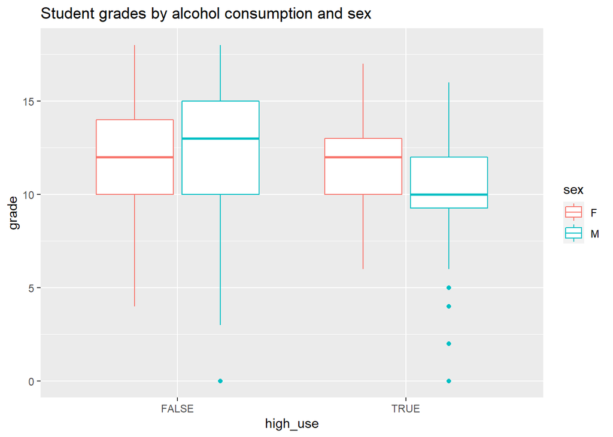

```r
ggplot(data_joined, aes(x = high_use, y = G3, col = sex)) + geom_boxplot() + ylab("grade") + ggtitle("Student grades by alcohol consumption and sex")
```

**Comments**:

- 41 females students over 195 (i.e. 21%) are higher alcohol users.
- 70 males students over 175 (i.e. 40%) are higher alcohol users. With these two comments, one can argue that *H2* is satisfied.
- On average, males alcohol user tend to have lower grades (2 points less than non-alcohol users).
- For females, grades point average is quite the same for alcohol and non-alcohol users.
- Looking at the boxplot, the non-alcohol user students have high grades. Especially, males, their median grade point is higher than females.
- Higher alcohol user students tend to have lower grades **(*H1* satisfied)**
- For higher alcohol users, females tend to have a high median grade point than males.